# STAT5003 Group Project Final Report

Group 50

2023-11-08

```r
library(tidyverse)
library(caret)
library(fastDummies)
library(UBL)
library(corrplot)
library(tidyfst)
library(nnet)
library(pROC)
library(class)
library(ranger)
library(naivebayes)
library(naniar)
library(kableExtra)
library(reshape2)
library(glmnet)
library(gridExtra)

globalsize = 11
global_legendsize = 0.5
```

# 1 Overview of the Problem

In the ever-evolving e-commerce space, it is critical to understand market dynamics, consumer behaviour and trends.” The “Olist Brazil E-Commerce Public Dataset” represents an invaluable resource for researchers and analysts seeking insight into the e-commerce industry over a specific period of time.

This dataset was obtained from the Kaggle website ([Brazilian E-Commerce Public Dataset by Olist](https://www.kaggle.com/datasets/olistbr/brazilian-ecommerce)). The license code for the dataset is: CC BY-NC-SA 4.0. The dataset has information of 100k orders from 2016 to 2018 made at multiple marketplaces in Brazil. Its features allows viewing an order from multiple dimensions: from order status, price, payment and freight performance to customer location, product attributes and finally reviews written by customers.

This dataset was chosen because it provides a comprehensive snapshot of the Brazilian e-commerce sector over a specific period of time. Not only does it reflect the developments and challenges facing the Brazilian e-commerce sector, but it also provides a rich source of information for those interested in studying consumer preferences, supply chain operations, and the booming industry. Our target is to predict the customer review score (1-5) from relevant information about each purchase.

# 2 Dataset Description

It contains nine subsets of data, eight of which were then combined by R code. The combination was done mainly through column variables about IDs. After collation, the dataset has a total of 23 attributes and 118146 Rows. The attributes are as follows:

```r
# data load-in and cleaning code
# path to the folder containing the datasets
path = "../data/BrazillianOlist/"

customers = read.csv(paste0(path, "olist_customers_dataset.csv"))
# geoloc = read.csv("data/BrazillianOlist/olist_geolocation_dataset.csv")
order_items = read.csv(paste0(path, "olist_order_items_dataset.csv"))
order_payments = read.csv(paste0(path, "olist_order_payments_dataset.csv"))
order_reviews = read.csv(paste0(path, "olist_order_reviews_dataset.csv"))
orders = read.csv(paste0(path, "olist_orders_dataset.csv"))
products = read.csv(paste0(path, "olist_products_dataset.csv"))
sellers = read.csv(paste0(path, "olist_sellers_dataset.csv"))
category_translation = read.csv(paste0(path, "product_category_name_translation.csv"), header = TRUE)
colnames(category_translation)[1] = "product_category_name"

# outer-joins retaining all entries in order_reviews, as review_score is our target
combined = order_reviews %>%
  left_join(orders, by = join_by(order_id)) %>%
  left_join(customers, by = join_by(customer_id)) %>%
  left_join(order_items, by = join_by(order_id), relationship = "many-to-many") %>%        # note there are multiple items per order_id, however this only generates more sample for us to work on?
  left_join(sellers, by = join_by(seller_id)) %>%
  left_join(products, by = join_by(product_id)) %>%
  left_join(order_payments, by = join_by(order_id), relationship = "many-to-many") %>%      # and multiple payments per order_id
  left_join(category_translation, by = join_by(product_category_name))

# replace all empty strings with NA
combined[combined == ""] = NA

# drop all unhelpful columns, all ids removed - Anonymization; keep order_id and order_item_id to count number of items in each order later
combined_trimmed = combined %>%
  select(-c(review_comment_title,
            review_comment_message,
            review_creation_date,
            review_answer_timestamp,
            review_id,
            product_category_name,
            customer_id,
            customer_unique_id,
            product_id,
            seller_id,
            shipping_limit_date,
            order_approved_at,
            payment_sequential,
            # abandoning city & zip code columns as too much details, justify by anonymity?
            seller_city,
            customer_city,
            seller_zip_code_prefix,
            customer_zip_code_prefix)) %>%
  # review score can't be NA as we are using it as the response
  filter(!is.na(review_score)) %>%
  # rename two typos in column names
  rename("product_name_length" = "product_name_lenght",
         "product_description_length" = "product_description_lenght") %>%
  # transform date columns into datetime object
  mutate(across(c(order_purchase_timestamp,
                  order_delivered_carrier_date,
                  order_delivered_customer_date,
                  order_estimated_delivery_date), ymd_hms))

# save(combined_trimmed, file = "data/combined_trimmed.RData")
```

- order_id
- review_score
- order_status
- order_purchase_timestamp
- order_delivered_carrier_date
- order_delivered_customer_date
- order_estimated_delivery_date
- customer_state
- order_item_id
- price
- freight_value
- seller_state
- product_name_length
- product_description_length
- product_photos_qty
- product_weight_g
- product_length_cm
- product_height_cm
- product_width_cm
- payment_type
- payment_installments
- payment_value
- product_category_name_english

By performing data statistics on the dataset, we find that the dataset contains 6 columns of `CHARACTER` data, 4 columns of `TIME` data, and 13 columns of `NUMERIC` data.

The collated data mainly contains data on the order number, and data on the date the item was sent out and the date the customer received the item. It also contains data on the price of the item, as well as the basic information about the item and the size of the item. The data set also contains customer reviews data, which was collected through surveys sent out to customers after purchase.

# 3 Initial Data Analysis & Feature Engineering

The full dataset is combined from the 8 smaller datasets detailing various aspects of the purchases made at Olist. All unique id numbers and the geo-location of customers and sellers are removed from the dataset to ensure anonymity. All features that would appear along with the reviews are also removed, as we would not have such information when we would like to predict the review score.

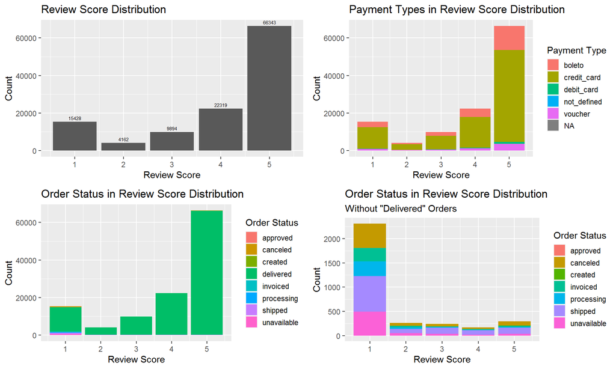

Figure 3.1: Barplot of review scores.

```r
load("data/combined_trimmed.RData")
# Histogram of review_score (KEEP)
p1 = combined_trimmed %>%
  ggplot(aes(x = review_score)) +
  geom_bar() +
  geom_text(aes(label = after_stat(count)), stat = "count", vjust = -0.5, size = 2) +
  labs(title = "Review Score Distribution",
       x = "Review Score", y = "Count") +
  theme_gray(base_size = globalsize)

# Histogram of review_score, coloured by payment_type
p2 = combined_trimmed %>%
  ggplot(aes(x = review_score, fill = payment_type)) +
  geom_bar() +
  labs(title = "Payment Types in Review Score Distribution",
       x = "Review Score", y = "Count",
       fill = "Payment Type") +
  theme_gray(base_size = globalsize) +
  theme(legend.key.size = unit(global_legendsize, 'cm'))

# Histogram of review_score, coloured by order_status
p3 = combined_trimmed %>%
  ggplot(aes(x = review_score, fill = order_status)) +
  geom_bar() +
  labs(title = "Order Status in Review Score Distribution",
       x = "Review Score", y = "Count",
       fill = "Order Status") +
  theme_gray(base_size = globalsize) +
  theme(legend.key.size = unit(global_legendsize, 'cm'))

# Histogram of review_score, coloured by order_status, without the delivered orders
p4 = combined_trimmed %>%
  filter(order_status != "delivered") %>%
  ggplot(aes(x = review_score, fill = order_status)) +
  geom_bar() +
  labs(title = "Order Status in Review Score Distribution",
       subtitle = "Without \"Delivered\" Orders",
       x = "Review Score", y = "Count",
       fill = "Order Status") +
  theme_gray(base_size = globalsize) +
  theme(legend.key.size = unit(global_legendsize, 'cm'))

grid.arrange(p1, p2, p3, p4, nrow = 2)
```

As we can see from the barplot Figure 3.1, the number of observations is imbalanced across different review scores. This could pose problems when trying to establish a model to predict the review score. Noticeably, the orders that had not been delivered (`order_status` $\neq$ “delivered”) had the highest proportion of review score 1. Thus, the order status is deemed a valuable predictor for the review score.

```r
# generate number of items per order, to used instead of the order_item_id
df_nitems_per_order = combined_trimmed %>%
  select(order_id, order_item_id) %>%
  group_by(order_id) %>%
  summarise(n_items_per_order = max(order_item_id))
# df_nitems_per_order

# combine into the dataset, generate days columns
df_final = combined_trimmed %>%
  left_join(df_nitems_per_order, by = join_by(order_id)) %>%
  # remove order_id and order_item_id, now that we have n_items_per_order
  select(-order_id, -order_item_id) %>%
  # generate days attributes
  mutate(
    real_delivered_days = as.numeric(order_delivered_customer_date - order_purchase_timestamp, unit = "days")
  ) %>%
  # remove timestamp columns
  select(-c(order_purchase_timestamp, order_delivered_carrier_date, order_delivered_customer_date, order_estimated_delivery_date)) %>%
  # generate product volume, remove dimensions cols
  mutate(
    product_volume_cm3 = product_length_cm * product_height_cm * product_width_cm
    ) %>%
  select(-product_length_cm, -product_width_cm, -product_height_cm)

cat_cols = c("review_score", "order_status", "customer_state", "seller_state", "payment_type",  "product_category_name_english")
num_cols = c("price", "freight_value", "product_name_length", "product_description_length", "product_photos_qty", "product_weight_g", "payment_installments", "payment_value", "n_items_per_order", "real_delivered_days", "product_volume_cm3")

# combined_transformed %>% glimpse()
df_final2 = df_final %>% mutate(across(cat_cols, as.factor))
```

The dataset contains several timestamp columns, which would be hard to use in any machine learning algorithm. Thus, in order to utilise the time data in our model, we have generated the number of days it took for an order to reach the customer by subtracting the actual delivery date from the purchase timestamp. The sequential labels of items in each order have been summarised into the the number of items in each order. The resultant dataframe has the following columns:

- review_score
- order_status
- customer_state
- price
- freight_value
- seller_state
- product_name_length
- product_description_length
- product_photos_qty
- product_weight_g
- payment_type
- payment_installments
- payment_value
- product_category_name_english
- n_items_per_order
- real_delivered_days
- product_volume_cm3

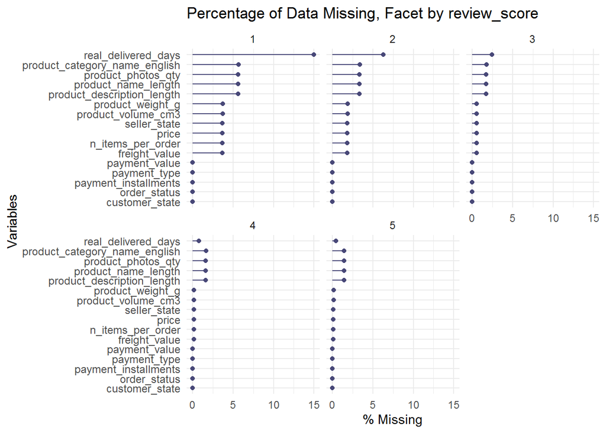

Figure 3.2: Missingness in data by review score.

```r
# Percent of data missing in each variable, in each review score
gg_miss_var(df_final2, show_pct = TRUE, facet = review_score) +
  labs(title = "Percentage of Data Missing, Facet by review_score") +
  theme(axis.text.y = element_text(size = 9))
```

As we have a very large dataset with 118146 rows, the missing values are only a small proportion in each variable (Figure 3.2, no more than 15% in each class). Removing the missing value rows would still leave us with sufficient data to train and fit our models. Thus, the rows with any attribute value missing are removed.

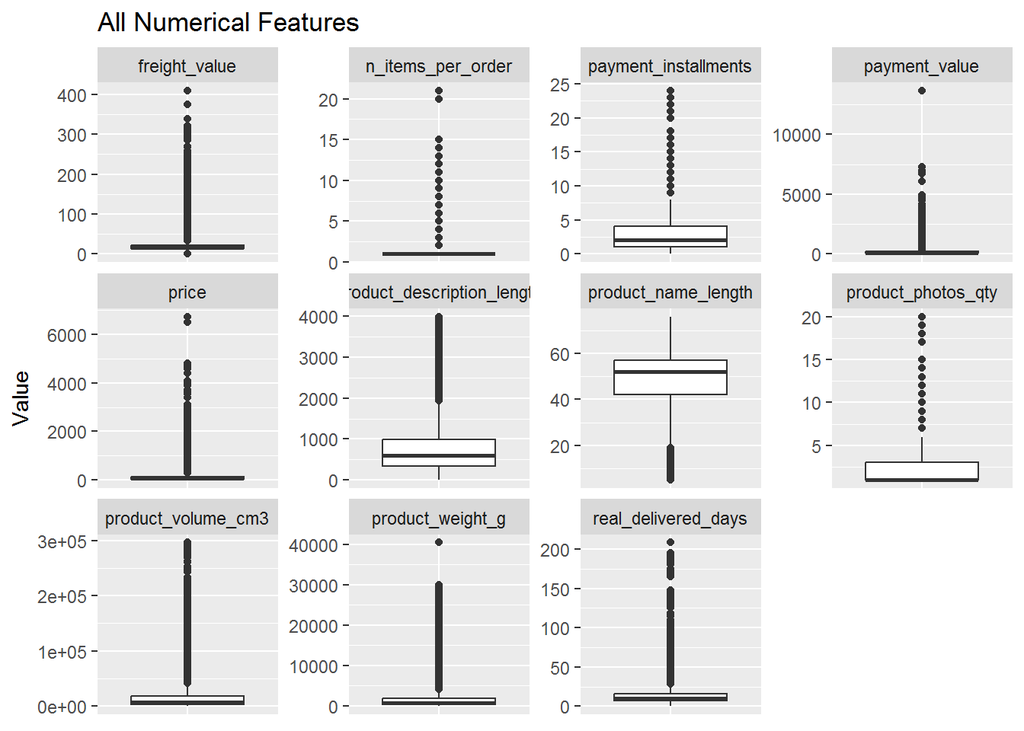

Figure 3.3: Numerical feature distributions before scaling.

```r
# check boxplot of all numerical features
df_final2 %>% select(num_cols) %>% remove_missing() %>%
  pivot_longer(cols = everything(), names_to = "col_name", values_to = "value") %>%
  ggplot(aes(x = factor(0), y = value)) +
  geom_boxplot() +
  labs(title = "All Numerical Features", y = "Value") +
  facet_wrap(vars(col_name), scales = "free_y") +
  theme(axis.ticks.x = element_blank(), axis.title.x = element_blank(), axis.text.x = element_blank())
```

When plotting the distributions of all the numerical features (Figure 3.3), we can see some outliers that are noticeably further away from the other data points. For example, n > 20 items per order, payment value > 10000, and product weight > 35000 (g). These outliers, along with any unreasonable edge values such as 0 in number of items per order and 0 in product weight, are removed from our dataset. Figure 3.3 also shows right-tail skewed distribution in all numerical features excepted for the product name length. These variables are thus log-transformed with the equation $\log (x + 1)$, in an attempt to make the features more normally distributed. The $1$ is added to deal with any potential zeros in the feature values. For many machine learning algorithms, it is often beneficial to have the predictors on the same scale. Although this is not the case for our random forest model, the logistic regression model does require the features on the same scale. Therefore, the numerical features are standardized using a mean of 0 and unit standard deviations.

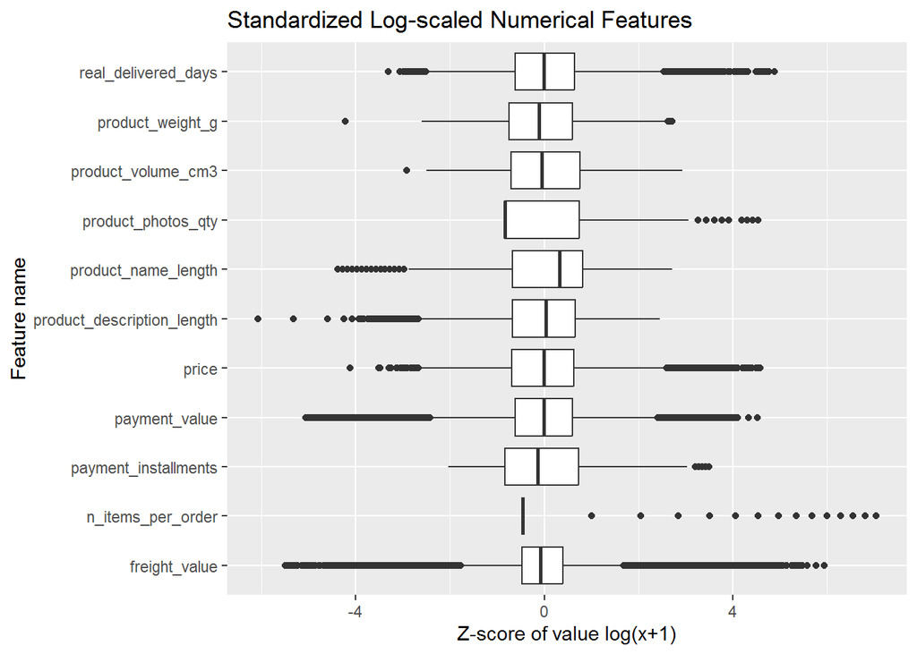

Figure 3.4: Numerical feature distributions after scaling.

```r
# remove rows with NA, and filter outliers and unreasonable values
df_final2_clean = df_final2 %>% remove_missing() %>%
  filter(n_items_per_order < 19,
         n_items_per_order > 0,
         payment_value < 10000,
         price < 6000,
         product_name_length > 0,
         product_weight_g < 35000,
         product_weight_g > 0) %>%
  # all numerical variables apart from product_name_length are right tail skewed, log transform them
  mutate(across(num_cols[!num_cols == "product_name_length"], ~log(.+1))) %>%
  # standardize numerical features, so that all features are on the same scale
  mutate(across(num_cols, ~as.vector(scale(.))))

# see boxplot of numerical variables of df2 (standardized log(x+1))
df_final2_clean %>% select(num_cols) %>%
  pivot_longer(cols = everything(), names_to = "col_name", values_to = "z_score") %>%
  ggplot(aes(y = col_name, x = z_score)) +
  geom_boxplot() +
  labs(title = "Standardized Log-scaled Numerical Features", y = "Feature name", x = "Z-score of value log(x+1)")
```

Figure 3.4 shows the distributions of the numerical features after the cleaning and transformations. The features are all on the same scale, albeit the number of items per order still has significant outliers. The cleaned dataset contains 113146 rows and 17 columns, of which 16 are features and one is the target, `review_score`. Upon further inspection on the categorical features, the product category name in English is not used in any of the models due to its complexity. A possibly better solution to utilise the category name could be using natural language processing (NLP), which is not discussed in this report.

# 4 Classification Algorithms Used

```r
# using pre-processed data
# dataset with un-encoded categorical variables, drop product category name column
# df_final_clean = read.csv(file = "../data/df_final_clean_unencoded.csv", header = TRUE)
# df_final2_clean %>% glimpse()

cat_cols = c("review_score", "order_status", "customer_state", "seller_state", "payment_type")
num_cols = c("price", "freight_value", "product_name_length", "product_description_length", "product_photos_qty", "product_weight_g", "payment_installments", "payment_value", "n_items_per_order", "real_delivered_days", "product_volume_cm3")

df_final2_clean = df_final2_clean %>% mutate(across(cat_cols, as.factor)) %>% select(-product_category_name_english)

# features/target variables split
X = df_final2_clean %>% select(-review_score)
y = df_final2_clean$review_score

# train (75%) test (25%) split
set.seed(5003)
inTrain = createDataPartition(y, p = 0.75)[[1]]
train_data = df_final2_clean[inTrain, ]
test_data = df_final2_clean[-inTrain, ]
X_train = X[inTrain, ]
X_test = X[-inTrain, ]
y_train = y[inTrain]
y_test = y[-inTrain]

# dummy-encode categorical columns and drop original categorical columns
X_train_dummied = dummy_cols(X_train) %>% select(where(is.numeric))
X_test_dummied = dummy_cols(X_test) %>% select(where(is.numeric))

# initiate performance metrics df for storing accuracy and AUC data
perform_df = tibble(
  Model = c("Logistic Regression", "k-Nearest Neighbors", "Random Forest", "Naïve Bayes"),
  Accuracy = rep(-1, 4),
  AUC = rep(-1, 4))

# initiate a list to store all confusion matrices
conf_mats = c()
```

Four classification algorithms are implemented on the training data, including logistic regression, $k$-nearest neighbours ($k$NN), random forest (RF) and Naïve Bayes (NB).

## 4.1 Logistic Regression

The original review score in the dataset has 5 classes, which were integers from 1 to 5. A logistic regression is usually used in binary classification. Here we have generated a binary review score variable where 1 represents good reviews (review score 4 and 5) and 0 represents bad reviews (review score 1, 2 and 3). In the following parts, we attempt to perform classification using multiple variations of a logistic regression model, on both the original ordinal review score (1-5) and the binary review score (0 and 1).

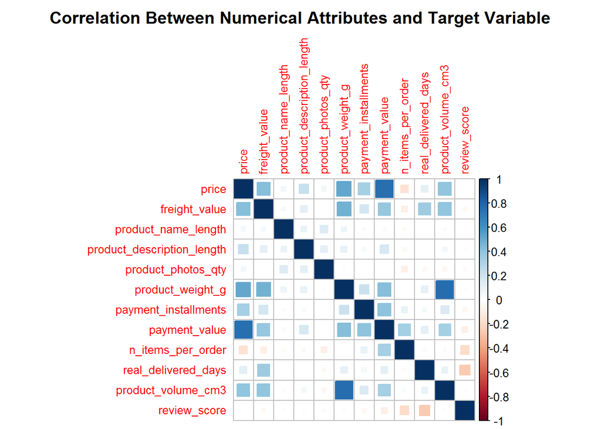

Figure 4.1: Correlation Plot

```r
# select only numerical columns and review score as numeric, plot correlation matrix
correlations <- cor(df_final2_clean %>% select(num_cols, review_score) %>% mutate(across(review_score, as.numeric)))
corrplot(correlations, method="square", tl.cex=0.8, title = "Correlation Between Numerical Attributes and Target Variable", mar = c(0,0,2,0))
```

Through the correlation plot (Figure 4.1), we can see that only the number of items per order (`n_item_per_order`) and the number of days it took for the order to reach customers (`real_delivered_days`) seem to have relatively significant impact on the review score. The price is highly correlated to the payment value and the product weight, and the product weight seems to be highly correlated with the product volume. The multicollinearity can have a negative impact on the model performance, however, for consistency between the different models we have kept all the independent variables in the logistic regression model.

### 4.1.1 Multinominal Classification

The `multinom` function from the `nnet` package is then used for fitting the model because it can be used to process multi-class classification data. The function utilises neural network to compute the probability of belonging to each class. Dummy-variables are created for each of the (n-1) categories in the categorical features.

```r
# multi-class logistic regression classification using nnet package
regr_logistic <- nnet::multinom(review_score ~ ., data = cbind(X_train_dummied, review_score = y_train))

save(regr_logistic, file = "data/regr_logistic.RData")
```

```r
load(file = "data/regr_logistic.RData")

#train set prediction
pre_train_logistic <- predict(regr_logistic, newdata = X_train_dummied, type = "class")
#train set prediction, class probabilities
pre_train_logistic_prob <- predict(regr_logistic, newdata = X_train_dummied, type = "prob")

#test set prediction
pre_test_logistic <- predict(regr_logistic, newdata = X_test_dummied, type = "class")
#test set prediction, class probabilities
pre_test_logistic_prob <- predict(regr_logistic, newdata = X_test_dummied, type = "prob")

confmat_logit_train = confusionMatrix(pre_train_logistic, y_train)
confmat_logit_test = confusionMatrix(pre_test_logistic, y_test)

conf_mats[["logit"]] = confmat_logit_test
# performance metrics (multinom)
# confmat_logit_test$byClass

#ROC
roc_train_logistic <- multiclass.roc(y_train, pre_train_logistic_prob)
roc_test_logistic <- multiclass.roc(y_test, pre_test_logistic_prob)

##auc train
auc_train = roc_train_logistic[["auc"]] %>% round(2)
#auc test
auc_test = roc_test_logistic[["auc"]] %>% round(2)

accuracy <- confmat_logit_test$overall["Accuracy"] %>% round(2)

perform_df$Accuracy[perform_df$Model == "Logistic Regression"] = confmat_logit_test$overall["Accuracy"]
perform_df$AUC[perform_df$Model == "Logistic Regression"] = roc_test_logistic[["auc"]]
```

Through calculations, AUC is around 0.60 and the accuracy is 0.59, which is not particularly high in this multiclass problem.

```r
# see https://www.bookdown.org/rwnahhas/RMPH/blr-ordinal.html
# ordinal logistic regression multi-class classification, Hess = TRUE to return the Hessian (the observed information matrix)
ord_logit_model <- MASS::polr(review_score ~ order_status + customer_state + price + freight_value + seller_state + product_name_length + product_description_length + product_photos_qty + product_weight_g + payment_type + payment_installments + payment_value + n_items_per_order + real_delivered_days + product_volume_cm3, data = train_data, Hess = TRUE)
# summary(ord_logit_model, digits = 2)
save(ord_logit_model, file = "data/ord_logit_model.RData")

load(file = "data/ord_logit_model.RData")
summary(ord_logit_model)

# model can fit, but predict generates Error, don't know how to fix

# pred_ord_logit_train = predict(ord_logit_model, newdata = X_train, type = "class")
# pred_ord_logit_test = predict(ord_logit_model, test_data, type = "class")
```

### 4.1.2 Binary Classification

The `glm` function is commonly used to fit logistic regression models in binary classification problems. The function is very powerful and highly versatile through the many choices of the `family` type. In the following model, we use the previously generated binary review score as our target prediction variable.

```r
# generate binary response variable, good reviews (4-5) = 1, bad reviews (1-3) = 0
y_binary = ifelse(as.numeric(y) >= 4, 1, 0) %>% as.factor()

# split into train and test set
y_train_binary = y_binary[inTrain]
y_test_binary = y_binary[-inTrain]
# glimpse(y_train_binary)

# binary logistic regression
regr_logistic_binary <- glm(binary_review_score ~ ., data = cbind(X_train_dummied, binary_review_score = y_train_binary), family = binomial(link = "logit"))

#train set prediction class probabilities
pre_train_logistic_binary <- predict(regr_logistic_binary, newdata = X_train_dummied, type = "response")

#test set prediction class probabilities
pre_test_logistic_binary <- predict(regr_logistic_binary, newdata = X_test_dummied, type = "response")

# Convert prediction probability to binary (0 or 1)
predicted_train_binary <- ifelse(pre_train_logistic_binary > 0.5, 1, 0) %>% as.factor()
predicted_test_binary <- ifelse(pre_test_logistic_binary > 0.5, 1, 0) %>% as.factor()

# train set confusion matrix (binary response)
confmat_logit_train_binary = confusionMatrix(predicted_train_binary, y_train_binary, positive = "1")
confmat_logit_test_binary = confusionMatrix(predicted_test_binary, y_test_binary, positive = "1")
```

```r
# performance metrics on test set(binary response)
# confmat_logit_test_binary
accuracy_binary = confmat_logit_test_binary$overall[["Accuracy"]]

#ROC
roc_train_logistic_binary <- multiclass.roc(y_train, pre_train_logistic_binary)
roc_test_logistic_binary <- multiclass.roc(y_test, pre_test_logistic_binary)

##auc train
auc_train_binary = roc_train_logistic_binary[["auc"]]
#auc test
auc_test_binary = roc_test_logistic_binary[["auc"]]
```

On the basis of `glm` functions, the binary classification on the review score results in a much higher accuracy of 0.78, which is expected, as logistic regression is more suitable for binary classification problems. The AUC is slightly increased to 0.64.

### 4.1.3 Hyperparameter Tuning

```r
# not evaluated when compiling
# hyperparameter tuning
pre_test_logistic_binary <- as.numeric(pre_test_logistic_binary)
train$binary_review_score<-factor(make.names(train$binary_review_score))

TC <- trainControl(method = "cv",number = 20)

gs_binary <- expand.grid(alpha = seq(0, 1, by = 0.1),
                    lambda = seq(0.001, 1, by = 0.01))

Binary_model_cv <- train(binary_review_score ~ ., data = cbind(X_train_dummied, binary_review_score = y_train_binary), method = "glmnet",trControl = TC,tuneGrid = gs_binary)

print(Binary_model_cv)
```

```r
## cv runs for too long, trying simple fit with best params
# Best_TG <- expand.grid(alpha = 0.6, lambda = 0.001)
# TC <- trainControl(method = "cv",number = 20)
#
# Final_binary_model_cv <- train(binary_review_score ~ ., data = cbind(X_train_dummied, binary_review_score = y_train_binary), method = "glmnet",trControl = TC,tuneGrid = Best_TG)
#
# print(Final_binary_model_cv)

Final_binary_model = glmnet::glmnet(x = X_train_dummied, y = y_train_binary, family = "binomial", alpha = 0.6, lambda = 0.01)

final_pred_binary = predict(Final_binary_model, newx = as.matrix(X_test_dummied), type = "class")[,1] %>% as.factor()

confmat_final_binary = confusionMatrix(final_pred_binary, y_test_binary)
confmat_final_binary

accuracy_final_binary = confmat_final_binary$overall[["Accuracy"]]
```

The final accuracy for predicting the binary review score is 0.78, which is about the same as before. There is no significant difference in performance between these two models in predicting the binary review scores, which indicates that the model before hyperparameter tuning already has suitable parameters.

Converting to binary data may not be a good choice, as it differs from the original dataset. This may lead to losing information from the dataset and the categories are not balanced. Ordinal logistic regression may be a more suitable model for our research question.

## 4.2 $k$-Nearest Neighbours (KNN)

```r
# knn using only payment type as a categorical predictor
# one-hot encoding of payment_type column
data_norm <- df_final2_clean %>%
  select(-c('order_status', 'customer_state', 'seller_state'))

data_oneH <- select(dummy_cols(data_norm, select_columns = 'payment_type'), -'payment_type')
train_knn <- data_oneH[inTrain, ]
test_knn <- data_oneH[-inTrain, ]
```

We chose the k-NN model to predict this dataset because k-NN is a non-parametric and supervised model that could be applied to both classification and regression problems. Most of the preprocessing is finished in the previous procedure. There are three feature engineering techniques applied that aim to adjust the dataset, adapting the characteristics of the k-NN model.

**One-hot encoding.** All nominal data are transformed into dummy variables through one-hot encoding. There are two reasons: (a) the k-NN model needs numerical values to calculate the distances; (b) the new dataset, after executing one-hot encoding, may not cause high dimensionality.

**Oversampling or Undersampling.** Since the classes in this dataset are highly imbalanced in sample amount, all the predictive results tend toward class 5. This situation may worsen the performance of k-NN because most of the neighbours around one observation are more likely to belong to the majority classes. We tried to increase the number of samples for minority groups, such as class 2 and 3, by applying functions like `SMOTE` or `mwmote`, or decrease the number of samples for majority groups, such as class 5; however, these attempts did not improve the model results.

### 4.2.1 Hyperparameter Tuning

```r
# not evaluated when compiling
k_value = 1
for (i in 1:20){
  pred <- knn(train = train_knn[,-1], test = test_knn[,-1], train_knn$review_score, k = i)
  k_value[i] <- 100 * sum(pred == test_knn$review_score) / length(test_knn$review_score)
  k = i
  cat(k,'=',k_value[i],'')
}
# save(k_value, file = "data/k_value.RData")
```

There are two most significant hyperparameters for the k-NN model: k value and distance. The k value is the number of neighbours around a sample point. A larger k value may cause underfitting, smooth decision boundary and loss of data information; a smaller k value may lead to overfitting, rough decision boundary and sensitivity to noise points. Distance measures the distance between two observations. Different distances determine different samples are selected as nearest neighbours. Some common distance metrics are Euclidean distance, Manhattan distance, Mahalanobis distance and Hamming distance.

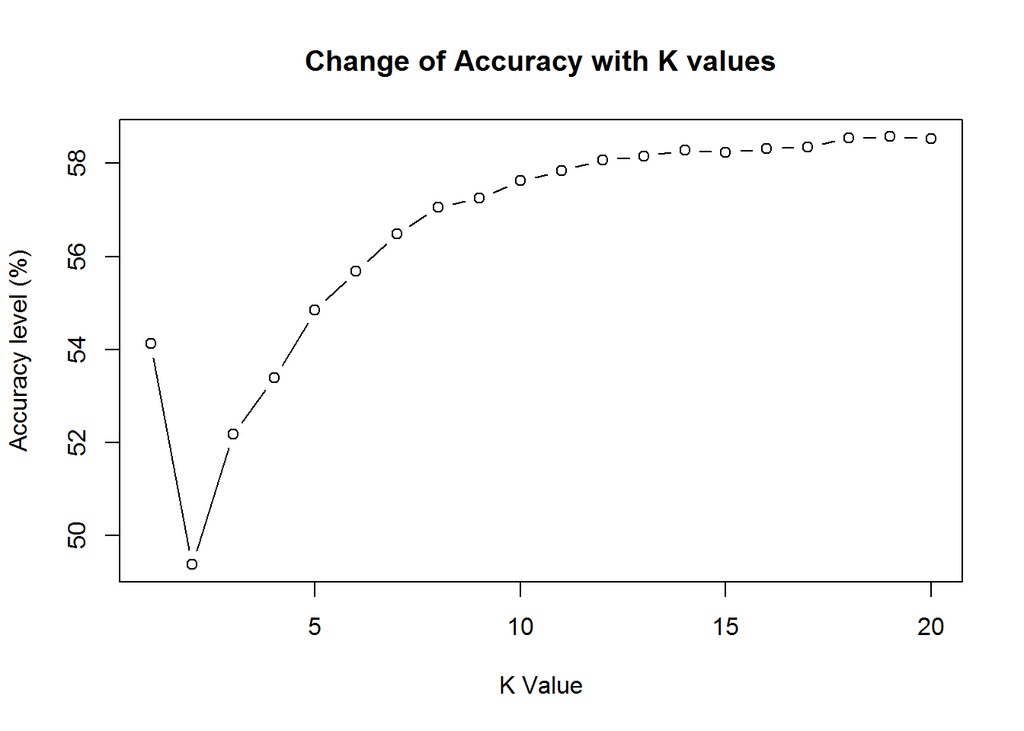

Figure 4.2: Change of knn model prediction accuracy with k values.

```r
# presaved computed knn data
load(file = "data/k_value.RData")
plot(k_value, type = "b", xlab = "K Value", ylab = "Accuracy level (%)", main = "Change of Accuracy with K values")
```

The best hyperparameters we have are when the k-value equals to 15 and Euclidean distance with 0.58 accuracy, where the accuracy stops to increase. (Figure 4.2)

### 4.2.2 Result and Model Evaluation

```r
pred_prob <- knn3Train(train = train_knn[, -1], test = test_knn[, -1], cl = train_knn$review_score, k = 15, prob = TRUE)
# save model prediction
# save(pred_prob, file = "data/knn_final_model_pred.RData")
```

```r
# load model prediction data
load(file = "data/knn_final_model_pred.RData")
pred = as.factor(pred_prob)
# View prediction results of test set.
accuracy <- sum(pred == test_knn$review_score) / length(test_knn$review_score)
# cat("Accuracy:", accuracy, "\n")
# table(test_data[, 'review_score'], pred)

# save accuracy and auc for test set
perform_df$Accuracy[perform_df$Model == "k-Nearest Neighbors"] = accuracy
perform_df$AUC[perform_df$Model == "k-Nearest Neighbors"] = multiclass.roc(y_test, attr(pred_prob, "prob")) %>% auc()

# save test set confusion matrix for knn
conf_mats[["knn"]] = confusionMatrix(pred, test_knn$review_score)

# Compute precision, recall and F1-score.
conM <- table(test_knn[, 'review_score'], pred)
prec <- numeric(nrow(conM))
recall <- numeric(nrow(conM))
f1 <- numeric(nrow(conM))

for(i in 1:nrow(conM)){
  tp <- conM[i, i]
  fp <- sum(conM[-i, i])
  fn <- sum(conM[i, -i])
  tn <- sum(conM) - tp - fp - fn

  prec[i] <- tp / (tp + fp)
  recall[i] <- tp / (tp + fn)
  f1[i] <- 2 * (prec[i] * recall[i]) / (prec[i] + recall[i])
}

# Create table.
table <- data.frame(Class = 1:nrow(conM),
                    Precision = prec,
                    Recall = recall,
                    F1_Score = f1)
table %>% round(2) %>%
  rename(`F1 Score` = "F1_Score") %>%
  kbl(caption = "Performance metrics for KNN (k = 15) model, per review score class basis.",
      format = "html",
      booktabs = TRUE,
      escape = TRUE) %>%
  kable_styling(bootstrap_options = c("condensed", "striped", "hover"),
                position = "center")
```

Table 4.1: Performance metrics for KNN (k = 15) model, per review score class basis.

| Class | Precision | Recall | F1 Score |
| --- | --- | --- | --- |
| 1 | 0.47 | 0.24 | 0.32 |
| 2 | 0.37 | 0.03 | 0.05 |
| 3 | 0.25 | 0.03 | 0.05 |
| 4 | 0.29 | 0.08 | 0.12 |
| 5 | 0.61 | 0.93 | 0.74 |

Using k = 15, the model’s performance is evaluated by accuracy, precision, recall and F1-score for each class, as shown in Table 4.1. As mentioned, the model is biased toward class 5, which is the majority group, resulting in poor outcomes for other classes.

### 4.2.3 Discussion

The k-NN model may be improved by executing better approaches for choosing features and solving imbalance-class problems. This procedure is necessary since k-NN is sensitive to outliers, imbalanced-class data and irrelevant attributes. Reducing computational complexity is a significant problem that needs to be considered when using k-NN. Techniques such as KD-trees, fast approximate similarity search and locality-sensitive hashing may be beneficial.

## 4.3 Random Forest

### 4.3.1 Class Imbalance

```r
# , fig.cap="Class imbalance in training set."

# investigate class imbalance in train set
plt_imb = train_data %>%
  ggplot(aes(x = review_score)) +
  geom_bar() +
  labs(x = "Review score", y = "Frequency", title = "Training Set") +
  theme_gray(base_size = globalsize)
```

```r
# , fig.cap="Class balanced after SMOTEd data."
set.seed(5003)
# smote with class 2 and 5, does not result in balanced classes, SMOTE has been removed from CRAN
# decreases accuracy on test set grossly
# new_train = SMOTE(review_score ~ ., data = train_data, perc.over = 120, perc.under = 100)
# smote with UBL package, dist="HEOM" or "HVDM" for mixed nominal and numerical features
new_train = SmoteClassif(review_score ~ ., dat = train_data, dist = "HEOM")

# rose only works on binary response
# new_train = ROSE(review_score ~ ., data = train_data, seed = 5003)

# up-sample/down-sample from caret
# new_train = upSample(X_train, y_train) %>% rename(review_score = Class)

# glimpse(new_train)
# investigate class imbalance in resampled data
plt_smoted = new_train %>%
  ggplot(aes(x = review_score)) +
  geom_bar() +
  labs(x = "Review score", y = "Frequency", title = "Training Set after SMOTE") +
  theme_gray(base_size = globalsize)
```

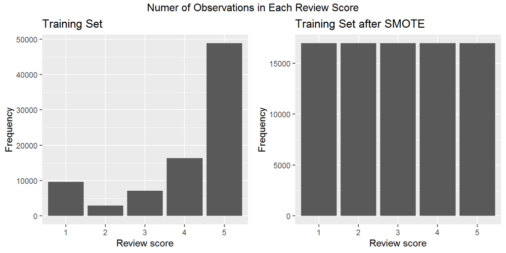

Figure 4.3: Class imbalance in training set, before and after SMOTE.

```r
# , fig.dim=c(6,5)
grid.arrange(plt_imb, plt_smoted, nrow = 1, top = "Numer of Observations in Each Review Score")
```

From Figure 4.3, we can see that the number of observations are imbalanced across the difference review scores. The class 5 has noticeably more observations than the other classes. The model performs well on predicting the class 5, however, the false positive is also high in class 5. To reduce the impact of imbalanced data, we have used the SMOTE algorithm to resample the data. The function `SmoteClassif` from the `UBL` package is used, with the distance parameter `HEOM`. After resampling, we can see that the number of observations are now uniform across all classes. (Figure 4.3)

```r
# rf using fixed number of trees
X_train_new = new_train %>% select(-review_score)
y_train_new = new_train$review_score

# rf_model = ranger(x = X_train, y = y_train, importance = "impurity", num.trees = 100, sample.fraction = c(.2, .35, .2, .2, .05), replace = TRUE, keep.inbag = TRUE)
rf_model = ranger(x = X_train_new, y = y_train_new, importance = "impurity", num.trees = 100, replace = TRUE, keep.inbag = TRUE)
# test on test set
rf_predict <- predict(rf_model, X_test)$predictions
```

```r
# Accuracy on test set
accuracy <- sum(rf_predict == y_test) / nrow(X_test)
accuracy <- round(accuracy, 2)

# compute confusion matrix
confusion_mtx <- confusionMatrix(rf_predict, y_test)
# confusion_mtx

# calculate statistics for class
stati <- confusion_mtx$byClass

# f1 scores for each class
f1_scores <- 2 * (stati[,"Sensitivity"] * stati[,"Pos Pred Value"]) / (stati[,"Sensitivity"] + stati[,"Pos Pred Value"])

f1_scores <- round(f1_scores, 2)

avg_f1 <- round(mean(f1_scores, na.rm = TRUE), 2)
```

```r
rf_tbl1b = rbind(stati[,"Sensitivity"], f1_scores, stati[,"Balanced Accuracy"])
rownames(rf_tbl1b) = c("Sensitivity", "F1 score for each class", "Balanced Accuracy")
rf_tbl1b %>%
  kbl(caption = "Performance metrics of each class of the RF model on test set.",
      format = "html",
      booktabs = TRUE,
      digits = 2,
      escape = TRUE) %>%
  kable_styling(bootstrap_options = c("condensed", "striped", "hover"),
                position = "center")
```

Table 4.2: Performance metrics of each class of the RF model on test set.

|  | Class: 1 | Class: 2 | Class: 3 | Class: 4 | Class: 5 |
| --- | --- | --- | --- | --- | --- |
| Sensitivity | 0.61 | 0.27 | 0.28 | 0.46 | 0.54 |
| F1 score for each class | 0.53 | 0.28 | 0.27 | 0.36 | 0.62 |
| Balanced Accuracy | 0.76 | 0.62 | 0.60 | 0.60 | 0.63 |

The SMOTE processed data is trained using RF. Based on the confusion matrix and various performance metrics it can be concluded that the accuracy on the test set is about 0.50, which means that the model is able to correctly predict about 50% of the samples. Among the five classes, class1 has the highest sensitivity of about 0.61, which means that the model is able to correctly identify about 61% of the true positives on class1. Comparatively, class2 has a sensitivity of about 0.27, which indicates that the model is poorer at identifying class2 positives, misclassifying them as other categories. (Table 4.2)

Based on the F1 scores for each class, the F1 scores combine the precision and recall of the model. class5 has the highest F1 scores, and the model has relatively good predictive precision and recall on class5. The average F1 score is about 0.41, indicating that the overall predictive performance of the model on each class is relatively average.

Based on the above findings, RF has better predictive performance on class1 and class5 after SMOTE oversampling and average performance on other classes. (Table 4.2) This suggests that the SMOTE oversampling method may have led to a change in the distribution of the data, making certain classes more difficult to distinguish. Excessive oversampling may lead to increased overlap between categories and affect the generalisation ability of the model, which may be one of the reasons why the model continues to perform poorly on class2.

### 4.3.2 Hyperparameter Tuning

```r
# parameter range
ntree_values <- c(30, 40, 50)  # number of trees
mtry_values <- c(2, 3)         # number of randomly selected features

best_model <- NULL
highest_accuracy <- 0
best_ntree <- NULL
best_mtry <- NULL

# iterate parameters
for (ntree in ntree_values) {
  for (mtry in mtry_values) {

    rf_model <- ranger(x = X_train_new, y = y_train_new, ntree = ntree, mtry = mtry)
    rf_predict <- predict(rf_model, X_test)$predictions

    # accuracy
    accuracy <- round(sum(rf_predict == y_test) / nrow(X_test), 2)

    # If is best model, update the best model and  accuracy
    if (accuracy > highest_accuracy) {
      highest_accuracy <- accuracy
      best_model <- rf_model
      best_ntree <- ntree
      best_mtry <- mtry
    }

    # cat(paste("ntree:", ntree, "; mtry:", mtry, "; accuracy:", accuracy, "\n"))
  }
}

# cat(paste("best model: ntree:", best_ntree, "; mtry:", best_mtry, "; accuracy:", highest_accuracy))
```

```r
# 1.best model accuracy
# training
best_rf_model <- ranger(x = X_train_new, y = y_train_new, ntree=30, mtry=2, importance = "impurity", replace = TRUE, keep.inbag = TRUE)

# predictions
rf_train_predict <- predict(best_rf_model, X_train_new)$predictions
# rf_train_predict_prob = predict(best_rf_model, X_train_new, predict.all = TRUE)$predictions
rf_test_predict <- predict(best_rf_model, X_test)$predictions
rf_test_predict_prob <- predict(best_rf_model, X_test, predict.all = TRUE)$predictions
test_pred_prob = apply(rf_test_predict_prob, 1, function(x) summary(factor(x, levels = 1:5))/length(x), simplify = TRUE)

save(rf_train_predict, rf_test_predict, test_pred_prob, file = "data/best_rf_model_predicts.RData")
```

```r
load(file = "data/best_rf_model_predicts.RData")

# accuracy
train_accuracy <- sum(rf_train_predict == y_train_new) / nrow(X_train_new)
train_accuracy <- round(train_accuracy, 2)

test_accuracy <- sum(rf_test_predict == y_test) / nrow(X_test)
perform_df$Accuracy[perform_df$Model == "Random Forest"] = test_accuracy
test_accuracy <- round(test_accuracy, 2)

# auc ?
# calculated manually from ranger to achieve the same result as predict.randomForest with type = "prob"
# see: https://stats.stackexchange.com/questions/226109/how-does-predict-randomforest-estimate-class-probabilities
rf_auc = multiclass.roc(y_test, t(test_pred_prob)) %>% auc()
perform_df$AUC[perform_df$Model == "Random Forest"] = rf_auc

# print
# cat("train set accuracy:", train_accuracy, "\n")
# cat("test set accuracy:", test_accuracy)

# 2. best model f1 score
# compute confusion matrix
confusion_mtx <- confusionMatrix(rf_test_predict,y_test)
# confusion_mtx
conf_mats[["rf"]] = confusion_mtx

# calculate statistics for class
stati <- confusion_mtx$byClass

# f1 scores for each class
f1_scores <- 2 * (stati[,"Sensitivity"] * stati[,"Pos Pred Value"]) / (stati[,"Sensitivity"] + stati[,"Pos Pred Value"])

f1_scores <- round(f1_scores, 2)
avg_f1 <- round(mean(f1_scores, na.rm = TRUE), 2)

# cat("F1 scores for each class:\n")
# print(f1_scores)
#
# cat("\naverage F1 score:", avg_f1)
```

In tuning the hyperparameters for RF, two key parameters were focused on: the number of decision trees (`ntree`) and the number of features randomly selected at each split (`mtry`). After iterations of manual search, it was found that the model performed best on the test set with an accuracy of about 0.53 when `ntree` was 30 and `mtry` was 2. Applying the optimal hyperparameter combination to the training model resulted in an accuracy of up to 0.98 on the training set and only 0.54 on the test set. this suggests that the model may suffer from an overfitting problem.

This phenomenon may be related to data augmentation performed by the SMOTE technique, which balances the distribution of categories in the dataset but potentially introduces noise when generating new samples, leading to overlearning of noise by the model. Subsequent consideration needs to be given to trying other data enhancement techniques, introducing regularisation methods, using boosting algorithms and other integrated strategies to improve the generalisation ability of the model.

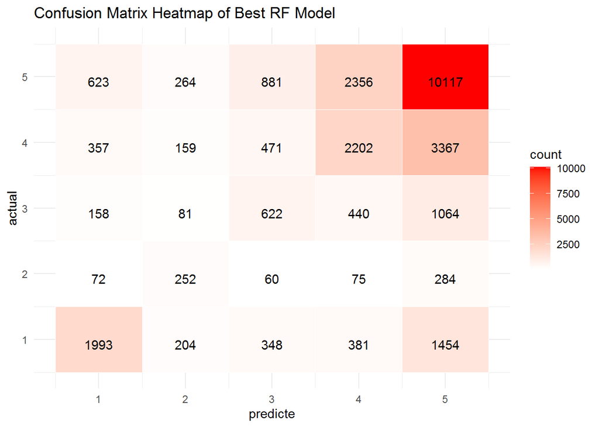

Figure 4.4: Confusion matrix heatmap for the best rf model.

```r
# 3.best model confusion matrix heatmap
cm <- confusion_mtx$table

cm_melted <- melt(as.matrix(cm))
colnames(cm_melted) <- c("Actual", "Predicted", "value")

# plot
ggplot(data = cm_melted, aes(x = Predicted, y = Actual)) +
  geom_tile(aes(fill = value), color = "white") +
  geom_text(aes(label = sprintf("%d", value)), vjust = 1) +
  scale_fill_gradient(low = "white", high = "red") +
  theme_minimal() +
  labs(x = 'predicte', y = 'actual', fill = 'count') +
  ggtitle('Confusion Matrix Heatmap of Best RF Model')
```

According to the confusion matrix heat map (Figure 4.4), the model performs well on class5, identifying 10117 true positives. There is a misclassification of other classes as Class5, which indicates that the model is biased towards class5. Especially for class2 and class3, the number of true positives is relatively low, implying that the model has not learnt enough features for these two classes.

In conjunction with previous points, data augmentation using SMOTE techniques may result in models that focus on noise during training, achieving high performance on the training set and poor performance on the test set. Subsequently, other data enhancement methods need to be considered to enhance the generalisation performance of the model.

## 4.4 Naïve Bayes

The Naïve Bayes model is widely employed in multiclass classification problems due to its simple modelling assumptions and lack of hyperparameters. Moreover, it is computationally efficient and adept at handling high-dimensional datasets. Upon importing and reviewing the dataset, a significant issue arises: the distribution of categories within the dataset is highly imbalanced. Notably, there are over 50,000 data instances belonging to category “5,” whereas category “2” comprises only around 3,800 instances. This data characteristic poses a substantial challenge to subsequent model training. Directly applying the model risks biasing predictions toward category “5”. To mitigate this, an initial step involves undersampling the dataset, ensuring a balanced representation of categories within both the training and test sets.

```r
# 欠采样
under_sampled_data <- df_final2_clean %>%
                      group_by(review_score) %>%
                      sample_n(size = 2000, replace = FALSE)

labels <- under_sampled_data$review_score
features <- under_sampled_data[, -which(names(under_sampled_data) == "review_score")]


inTrain <- createDataPartition(labels, p = 0.8)[[1]]

x_train <- features[inTrain, ]
x_test <- features[-inTrain, ]
y_train <- labels[inTrain]
y_test <- labels[-inTrain]
```

```r
y_train_fac <- factor(y_train)
y_test_fac <- factor(y_test)

naive_mod <- naive_bayes(y_train_fac ~ ., data = x_train)

naive_train_pre <- predict(naive_mod, newdata = x_train)
confusion_train <- confusionMatrix(naive_train_pre, y_train_fac)
accuracy_train <- confusion_train$overall["Accuracy"]

naive_pre <- predict(naive_mod, newdata = x_test)
naive_pre_prob <- predict(naive_mod, newdata = x_test, type = "prob")
confusion <- confusionMatrix(naive_pre, y_test_fac)
accuracy_test <- confusion$overall["Accuracy"]
nb_auc = multiclass.roc(y_test_fac, naive_pre_prob) %>% auc()

# save performance metrics to use later in conclusion
perform_df$Accuracy[perform_df$Model == "Naïve Bayes"] = accuracy_test
perform_df$AUC[perform_df$Model == "Naïve Bayes"] = nb_auc
conf_mats[["nb"]] = confusion

# print(paste("Accuracy on training set (2 d.p.s):", round(accuracy_train, 2), "\n"))
# print(paste("Accuracy on test set (2 d.p.s):", round(accuracy_test, 3)))
```

Following this balanced dataset split, the Naïve Bayes model is constructed using the `naive_bayes()` function from the `naivebayes` library in R. However, the model exhibits suboptimal performance, yielding an accuracy of 0.31 on the training set and a lower accuracy of 0.28 on the test set. Despite employing various techniques such as Lasso feature extraction, attempts to enhance model accuracy have proven unsuccessful. Further investigation is imperative to comprehend the precise reasons behind these limitations, warranting in-depth research and analysis.

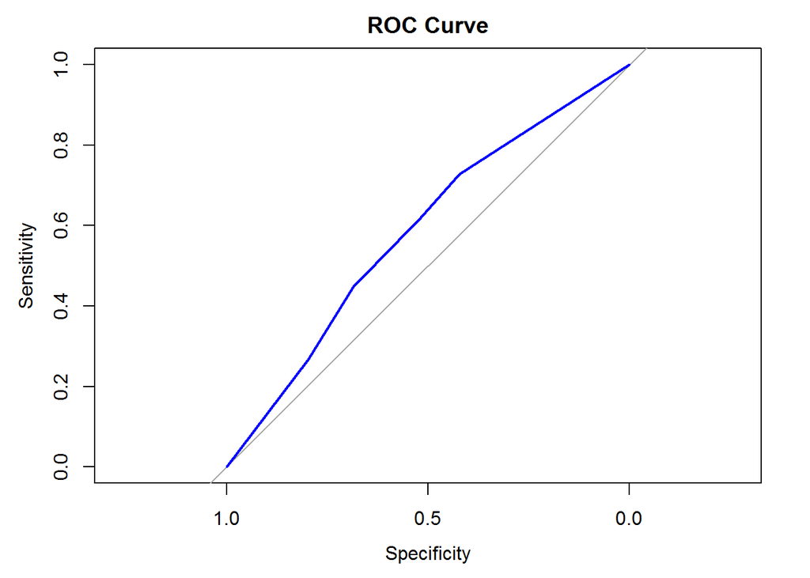

Figure 4.5: ROC curve of Naïve Bayes predictions on undersampled data.

```r
roc_curve <- roc(y_test, as.numeric(naive_pre))

plot(roc_curve, main="ROC Curve", col="blue", lwd=2)
```

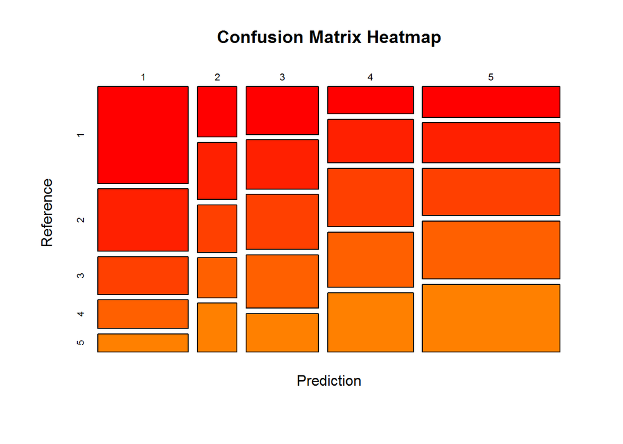

Figure 4.6: Confusion matrix of the Naïve Bayes predictions on undersampled data.

```r
plot(confusion$table, main = "Confusion Matrix Heatmap", col = heat.colors(12), scale = "none", digits = 3)
```

Nevertheless, a comprehensive exploration of the factors contributing to the plain Bayesian model’s lacklustre performance is imperative. This discrepancy could stem from inadequacies in the dataset’s preprocessing methods or, alternatively, from the inherent limitations of the plain Bayesian model’s assumptions. The latter, characterized by its simplistic assumption of feature column independence, may clash with the intricate interdependencies present in certain dataset features. This mismatch renders the plain Bayesian model ill-suited for precise predictions in this particular dataset. Further investigation is warranted to discern the precise sources of these challenges and refine the modelling approach accordingly.

# 5 Classification Performance Evaluation

```r
# manually entering previously computed by Ruizhe but not saved auc
# perform_df$AUC[perform_df$Model == "k-Nearest Neighbors"] = 0.52
# perform_df$AUC[perform_df$Model == "Random Forest"] = 0.61
# perform_df$AUC[perform_df$Model == "Naïve Bayes"] = 0.51

perform_df %>%
  kbl(caption = "Accuracy and area under the curve (AUC) of each model.",
      format = "html",
      booktabs = TRUE,
      escape = TRUE,
      digits = 2) %>%
  kable_styling(bootstrap_options = c("condensed", "striped", "hover"),
                position = "center")
```

Table 5.1: Accuracy and area under the curve (AUC) of each model.

| Model | Accuracy | AUC |
| --- | --- | --- |
| Logistic Regression | 0.59 | 0.60 |
| k-Nearest Neighbors | 0.58 | 0.62 |
| Random Forest | 0.54 | 0.73 |
| Naïve Bayes | 0.28 | 0.61 |

```r
# see the confusion matrix of each model for more performance metrics
f1_tab = tibble(
  conf_mats$logit$byClass[, "F1"],
  conf_mats$knn$byClass[, "F1"],
  conf_mats$rf$byClass[, "F1"],
  conf_mats$nb$byClass[, "F1"],
)
colnames(f1_tab) = perform_df$Model
f1_tab = t(f1_tab) %>% cbind(rowMeans(t(f1_tab), na.rm = TRUE))

colnames(f1_tab) = c("Class 1", "Class 2", "Class 3", "Class 4", "Class 5", "Average F1")
f1_tab %>%
  kbl(caption = "F1 scores of each class of each model.",
      format = "html",
      booktabs = TRUE,
      escape = TRUE,
      digits = 2) %>%
  kable_styling(bootstrap_options = c("condensed", "striped", "hover"),
                position = "center")
```

Table 5.2: F1 scores of each class of each model.

|  | Class 1 | Class 2 | Class 3 | Class 4 | Class 5 | Average F1 |
| --- | --- | --- | --- | --- | --- | --- |
| Logistic Regression | 0.27 | NA | NA | NA | 0.74 | 0.51 |
| k-Nearest Neighbors | 0.32 | 0.05 | 0.05 | 0.12 | 0.74 | 0.26 |
| Random Forest | 0.53 | 0.30 | 0.26 | 0.37 | 0.66 | 0.42 |
| Naïve Bayes | 0.41 | 0.15 | 0.21 | 0.23 | 0.34 | 0.27 |

Table 5.1 shows that the k-Nearest Neighbours and logistic regression (multiclass) have the highest accuracy. While Naïve Bayes and the random forest model models have lower accuracy. This may be due to their assumptions about the data distribution or the way the distance metric is not well suited to the problem.

The logistic regression model performed relatively well in these four models in terms of the average F1 score. All models except for Naïve Bayes have equally good performance on class5. Table 5.2 shows that the performance is relatively better on this class. Then all other classes are relatively poor. There are more improvements to be made in the upcoming work.

Next we’ll have the main three ways to improve it.

1. Choose the right model. We need to find out the most suitable model to complete this classification task.
2. Optimize feature engineering.
3. Tune hyperparameters. We need to discover the best hyperparameter combinations in the later task.

# 6 Conclusion

We may research for improvements from at least two directions in the future work:

**Model suitability**: we may find more suitable models or apply integration techniques, such as the SVM model and bagging or boosting method, to improve the stability and performance of this problem.

**Feature engineering**: we may more carefully conduct an analysis of the dataset and extract the most correlated features to the target variable to reduce the influence of irrelevant attributes.

# 7 References

[1]

R Core Team, *R: A language and environment for statistical computing*. Vienna, Austria: R Foundation for Statistical Computing, 2023. Available: https://www.R-project.org/

[2]

M. Kuhn, *Caret: Classification and regression training*. 2023. Available: https://github.com/topepo/caret/

[3]

B. Ripley, *Class: Functions for classification*. 2023. Available: http://www.stats.ox.ac.uk/pub/MASS4/

[4]

T. Wei and V. Simko, *Corrplot: Visualization of a correlation matrix*. 2021. Available: https://github.com/taiyun/corrplot

[5]

H. Wickham, R. François, L. Henry, K. Müller, and D. Vaughan, *Dplyr: A grammar of data manipulation*. 2023. Available: https://dplyr.tidyverse.org

[6]

J. Kaplan, *fastDummies: Fast creation of dummy (binary) columns and rows from categorical variables*. 2023. Available: https://github.com/jacobkap/fastDummies

[7]

H. Wickham, *Forcats: Tools for working with categorical variables (factors)*. 2023. Available: https://forcats.tidyverse.org/

[8]

H. Wickham *et al.*, *ggplot2: Create elegant data visualisations using the grammar of graphics*. 2023. Available: https://ggplot2.tidyverse.org

[9]

J. Friedman *et al.*, *Glmnet: Lasso and elastic-net regularized generalized linear models*. 2023. Available: https://glmnet.stanford.edu

[10]

E. Pebesma and B. Graeler, *Gstat: Spatial and spatio-temporal geostatistical modelling, prediction and simulation*. 2023. Available: https://github.com/r-spatial/gstat/

[11]

H. Zhu, *kableExtra: Construct complex table with kable and pipe syntax*. 2023. Available: http://haozhu233.github.io/kableExtra/

[12]

D. Sarkar, *Lattice: Trellis graphics for r*. 2023. Available: https://lattice.r-forge.r-project.org/

[13]

V. Spinu, G. Grolemund, and H. Wickham, *Lubridate: Make dealing with dates a little easier*. 2023. Available: https://lubridate.tidyverse.org

[14]

D. Bates, M. Maechler, and M. Jagan, *Matrix: Sparse and dense matrix classes and methods*. 2023. Available: https://Matrix.R-forge.R-project.org

[15]

M. Majka, *Naivebayes: High performance implementation of the naive bayes algorithm*. 2020. Available: https://github.com/majkamichal/naivebayes

[16]

N. Tierney, D. Cook, M. McBain, and C. Fay, *Naniar: Data structures, summaries, and visualisations for missing data*. 2023. Available: https://github.com/njtierney/naniar

[17]

B. Ripley, *Nnet: Feed-forward neural networks and multinomial log-linear models*. 2023. Available: http://www.stats.ox.ac.uk/pub/MASS4/

[18]

X. Robin *et al.*, *pROC: Display and analyze ROC curves*. 2023. Available: http://expasy.org/tools/pROC/

[19]

H. Wickham and L. Henry, *Purrr: Functional programming tools*. 2023. Available: https://purrr.tidyverse.org/

[20]

L. Breiman, A. Cutler, A. Liaw, and M. Wiener, *randomForest: Breiman and cutler’s random forests for classification and regression*. 2022. Available: https://www.stat.berkeley.edu/~breiman/RandomForests/

[21]

M. N. Wright, S. Wager, and P. Probst, *Ranger: A fast implementation of random forests*. 2023. Available: https://github.com/imbs-hl/ranger

[22]

H. Wickham, J. Hester, and J. Bryan, *Readr: Read rectangular text data*. 2023. Available: https://readr.tidyverse.org

[23]

H. Wickham, *reshape2: Flexibly reshape data: A reboot of the reshape package*. 2020. Available: https://github.com/hadley/reshape

[24]

E. Pebesma and R. Bivand, *Sp: Classes and methods for spatial data*. 2023. Available: https://github.com/edzer/sp/

[25]

H. Wickham, *Stringr: Simple, consistent wrappers for common string operations*. 2022. Available: https://stringr.tidyverse.org

[26]

K. Müller and H. Wickham, *Tibble: Simple data frames*. 2023. Available: https://tibble.tidyverse.org/

[27]

T.-Y. Huang, *Tidyfst: Tidy verbs for fast data manipulation*. 2023. Available: https://github.com/hope-data-science/tidyfst

[28]

H. Wickham, D. Vaughan, and M. Girlich, *Tidyr: Tidy messy data*. 2023. Available: https://tidyr.tidyverse.org

[29]

H. Wickham, *Tidyverse: Easily install and load the tidyverse*. 2023. Available: https://tidyverse.tidyverse.org

[30]

P. Branco, R. Ribeiro, and L. Torgo, *UBL: An implementation of re-sampling approaches to utility-based learning for both classification and regression tasks*. 2023. Available: https://github.com/paobranco/UBL

[31]

P. H. Hiemstra, E. J. Pebesma, C. J. W. Twenh"ofel, and G. B. M. Heuvelink, “Real-time automatic interpolation of ambient gamma dose rates from the dutch radioactivity monitoring network,” *Computers & Geosciences*, 2008.

[32]

Kuhn and Max, “Building predictive models in r using the caret package,” *Journal of Statistical Software*, vol. 28, no. 5, pp. 1–26, 2008, doi: 10.18637/jss.v028.i05.

[33]

W. N. Venables and B. D. Ripley, *Modern applied statistics with s*, Fourth. New York: Springer, 2002. Available: https://www.stats.ox.ac.uk/pub/MASS4/

[34]

T. Wei and V. Simko, *R package ’corrplot’: Visualization of a correlation matrix*. 2021. Available: https://github.com/taiyun/corrplot

[35]

H. Wickham, *ggplot2: Elegant graphics for data analysis*. Springer-Verlag New York, 2016. Available: https://ggplot2.tidyverse.org

[36]

J. Friedman, R. Tibshirani, and T. Hastie, “Regularization paths for generalized linear models via coordinate descent,” *Journal of Statistical Software*, vol. 33, no. 1, pp. 1–22, 2010, doi: 10.18637/jss.v033.i01.

[37]

N. Simon, J. Friedman, R. Tibshirani, and T. Hastie, “Regularization paths for cox’s proportional hazards model via coordinate descent,” *Journal of Statistical Software*, vol. 39, no. 5, pp. 1–13, 2011, doi: 10.18637/jss.v039.i05.

[38]

J. K. Tay, B. Narasimhan, and T. Hastie, “Elastic net regularization paths for all generalized linear models,” *Journal of Statistical Software*, vol. 106, no. 1, pp. 1–31, 2023, doi: 10.18637/jss.v106.i01.

[39]

E. J. Pebesma, “Multivariable geostatistics in S: The gstat package,” *Computers & Geosciences*, vol. 30, pp. 683–691, 2004.

[40]

B. Gräler, E. Pebesma, and G. Heuvelink, “Spatio-temporal interpolation using gstat,” *The R Journal*, vol. 8, pp. 204–218, 2016, Available: https://journal.r-project.org/archive/2016/RJ-2016-014/index.html

[41]

D. Sarkar, *Lattice: Multivariate data visualization with r*. New York: Springer, 2008. Available: http://lmdvr.r-forge.r-project.org

[42]

G. Grolemund and H. Wickham, “Dates and times made easy with lubridate,” *Journal of Statistical Software*, vol. 40, no. 3, pp. 1–25, 2011, Available: https://www.jstatsoft.org/v40/i03/

[43]

N. Tierney and D. Cook, “Expanding tidy data principles to facilitate missing data exploration, visualization and assessment of imputations,” *Journal of Statistical Software*, vol. 105, no. 7, pp. 1–31, 2023, doi: 10.18637/jss.v105.i07.

[44]

W. N. Venables and B. D. Ripley, *Modern applied statistics with s*, Fourth. New York: Springer, 2002. Available: https://www.stats.ox.ac.uk/pub/MASS4/

[45]

X. Robin *et al.*, “pROC: An open-source package for r and s+ to analyze and compare ROC curves,” *BMC Bioinformatics*, vol. 12, p. 77, 2011.

[46]

A. Liaw and M. Wiener, “Classification and regression by randomForest,” *R News*, vol. 2, no. 3, pp. 18–22, 2002, Available: https://CRAN.R-project.org/doc/Rnews/

[47]

M. N. Wright and A. Ziegler, “ranger: A fast implementation of random forests for high dimensional data in C++ and R,” *Journal of Statistical Software*, vol. 77, no. 1, pp. 1–17, 2017, doi: 10.18637/jss.v077.i01.

[48]

H. Wickham, “Reshaping data with the reshape package,” *Journal of Statistical Software*, vol. 21, no. 12, pp. 1–20, 2007, Available: http://www.jstatsoft.org/v21/i12/

[49]

E. J. Pebesma and R. Bivand, “Classes and methods for spatial data in R,” *R News*, vol. 5, no. 2, pp. 9–13, 2005, Available: https://CRAN.R-project.org/doc/Rnews/

[50]

R. S. Bivand, E. Pebesma, and V. Gomez-Rubio, *Applied spatial data analysis with R, second edition*. Springer, NY, 2013. Available: https://asdar-book.org/

[51]

T.-Y. Huang and B. Zhao, “Tidyfst: Tidy verbs for fast data manipulation,” *Journal of Open Source Software*, vol. 5, no. 52, p. 2388, 2020, doi: 10.21105/joss.02388.

[52]

H. Wickham *et al.*, “Welcome to the tidyverse,” *Journal of Open Source Software*, vol. 4, no. 43, p. 1686, 2019, doi: 10.21105/joss.01686.

[53]

P. Branco, R. P. Ribeiro, and L. Torgo, “UBL: An r package for utility-based learning,” *CoRR*, vol. abs/1604.08079, 2016.

[54]

D. J. Hand and R. J. Till, “A simple generalisation of the area under the ROC curve for multiple class classification problems,” *Machine Learning*, vol. 45, no. 2, pp. 171–186, 2001, doi: 10.1023/A:1010920819831.

[55]

K. Mallikharjuna Rao, G. Saikrishna, and K. Supriya, “Data preprocessing techniques: Emergence and selection towards machine learning models - a practical review using HPA dataset,” *Multimedia Tools and Applications*, vol. 82, no. 24, pp. 37177–37196, 2023, doi: 10.1007/s11042-023-15087-5.

[56]

C. Kang, Y. Huo, L. Xin, B. Tian, and B. Yu, “Feature selection and tumor classification for microarray data using relaxed lasso and generalized multi-class support vector machine,” *Journal of Theoretical Biology*, vol. 463, pp. 77–91, 2019, doi: https://doi.org/10.1016/j.jtbi.2018.12.010.

# Appendix A - Data Dictionary

| Attributes | Data type | Explanation |
| --- | --- | --- |
| order_id | Character | order unique identifier |
| review_score | Numeric | Note ranging from 1 to 5 given by the customer on a satisfaction survey |
| order_status | Character | Reference to the order status (delivered, shipped, etc) |
| order_purchase_timestamp | Datetime | Shows the purchase timestamp |
| order_delivered_carrier_date | Datetime | Shows the order posting timestamp |
| order_delivered_customer_date | Datetime | Shows the actual order delivery date to the customer |
| order_estimated_delivery_date | Datetime | Shows the estimated delivery date that was informed to customer at the purchase moment |
| customer_state | Character | customer state |
| order_item_id | Numeric | sequential number identifying number of items included in the same order |
| price | Numeric | item price |
| freight_value | Numeric | item freight value item (if an order has more than one item the freight value is split between items) |
| seller_state | Character | seller state |
| product_name_length | Numeric | number of characters extracted from the product name |
| product_description_length | Numeric | number of characters extracted from the product description |
| product_photos_qty | Numeric | number of product published photos |
| product_weight_g | Numeric | product weight measured in grams |
| product_length_cm | Numeric | product length measured in centimeters |
| product_height_cm | Numeric | product height measured in centimeters |
| product_width_cm | Numeric | product width measured in centimeters |
| payment_type | Character | method of payment chosen by the customer |
| payment_installments | Numeric | number of installments chosen by the customer |
| payment_value | Numeric | transaction value |
| product_category_name_english | Character | category name in English |

# Author Contributions

All members contributed equally towards this project.